# Unit Project 3 Project

## Analyses

```r
# Fixes a HTML compilation bug (ignore)
r = getOption("repos")
r["CRAN"] = "http://cran.us.r-project.org"
options(repos = r)
```

### Analysis 1: Chi-square Test of Independence

#### Analyst: Yiling Du

Topic for Analysis 1: test for the association between “Drive” variable and “Size” variable. Drive: the type of drive (FWD, RWD,AWD); Size: the size of car (Small, Midsized, Large). Each variable has three categories.

First, call the packages that are needed for the analysis:

```r
library(tidyverse)
#install.packages("sjstats")
library (sjstats)
library (pwr)
install.packages("car")
library (car)
```

Load Data:

```r
cars <- read.csv("./Cars2015.csv", header=T)
cars
```

| Make | Model | Type | LowPrice | HighPrice | Drive | CityMPG | HwyMPG | FuelCap | Length | Width | Wheelbase | Height | UTurn | Weight | Acc030 | Acc060 | QtrMile | PageNum | Size |
| --- | --- | --- | --- | --- | --- | --- | --- | --- | --- | --- | --- | --- | --- | --- | --- | --- | --- | --- | --- |
| Chevrolet | Spark | Hatchback | 12.270 | 25.560 | FWD | 30 | 39 | 9.0 | 145 | 63 | 94 | 61 | 34 | 2345 | 4.4 | 12.8 | 19.4 | 123 | Small |
| Hyundai | Accent | Hatchback | 14.745 | 17.495 | FWD | 28 | 37 | 11.4 | 172 | 67 | 101 | 57 | 37 | 2550 | 3.7 | 10.3 | 17.8 | 148 | Small |
| Kia | Rio | Sedan | 13.990 | 18.290 | FWD | 28 | 36 | 11.3 | 172 | 68 | 101 | 57 | 37 | 2575 | 3.5 | 9.5 | 17.3 | 163 | Small |
| Mitsubishi | Mirage | Hatchback | 12.995 | 15.395 | FWD | 37 | 44 | 9.2 | 149 | 66 | 97 | 59 | 32 | 2085 | 4.4 | 12.1 | 19.0 | 188 | Small |
| Nissan | Versa Note | Hatchback | 14.180 | 17.960 | FWD | 31 | 40 | 10.9 | 164 | 67 | 102 | 61 | 37 | 2470 | 4.0 | 10.9 | 18.2 | 196 | Small |
| Dodge | Dart | Sedan | 16.495 | 23.795 | FWD | 23 | 35 | 14.2 | 184 | 72 | 106 | 58 | 38 | 3260 | 3.4 | 9.3 | 17.2 | 128 | Small |
| Chevrolet | Cruze LS | Sedan | 16.170 | 25.660 | FWD | 24 | 36 | 15.6 | 181 | 71 | 106 | 58 | 38 | 3140 | 3.7 | 9.8 | 17.6 | 119 | Small |
| Fiat | 500L | Hatchback | 19.345 | 24.695 | FWD | 24 | 33 | 13.1 | 167 | 70 | 103 | 66 | 37 | 3330 | 3.9 | 9.5 | 17.4 | 131 | Small |
| Ford | Focus | Hatchback | 17.170 | 29.170 | FWD | 28 | 38 | 12.4 | 179 | 72 | 104 | 58 | 39 | 2990 | 3.4 | 9.2 | 17.1 | 136 | Small |
| Toyoto | Yaris | Hatchback | 14.845 | 17.629 | FWD | 30 | 35 | 11.1 | 154 | 67 | 99 | 59 | 34 | 2385 | 3.9 | 10.8 | 18.3 | 216 | Small |

[output cut: 100 more lines]

```r
str(cars)
```

```
## 'data.frame':    110 obs. of  20 variables:
##  $ Make     : chr  "Chevrolet" "Hyundai" "Kia" "Mitsubishi" ...
##  $ Model    : chr  "Spark" "Accent" "Rio" "Mirage" ...
##  $ Type     : chr  "Hatchback" "Hatchback" "Sedan" "Hatchback" ...
##  $ LowPrice : num  12.3 14.7 14 13 14.2 ...
##  $ HighPrice: num  25.6 17.5 18.3 15.4 18 ...
##  $ Drive    : chr  "FWD" "FWD" "FWD" "FWD" ...
##  $ CityMPG  : int  30 28 28 37 31 23 24 24 28 30 ...
##  $ HwyMPG   : int  39 37 36 44 40 35 36 33 38 35 ...
##  $ FuelCap  : num  9 11.4 11.3 9.2 10.9 14.2 15.6 13.1 12.4 11.1 ...
##  $ Length   : int  145 172 172 149 164 184 181 167 179 154 ...
##  $ Width    : int  63 67 68 66 67 72 71 70 72 67 ...
##  $ Wheelbase: int  94 101 101 97 102 106 106 103 104 99 ...
##  $ Height   : int  61 57 57 59 61 58 58 66 58 59 ...
##  $ UTurn    : int  34 37 37 32 37 38 38 37 39 34 ...
##  $ Weight   : int  2345 2550 2575 2085 2470 3260 3140 3330 2990 2385 ...
##  $ Acc030   : num  4.4 3.7 3.5 4.4 4 3.4 3.7 3.9 3.4 3.9 ...
##  $ Acc060   : num  12.8 10.3 9.5 12.1 10.9 9.3 9.8 9.5 9.2 10.8 ...
##  $ QtrMile  : num  19.4 17.8 17.3 19 18.2 17.2 17.6 17.4 17.1 18.3 ...
##  $ PageNum  : int  123 148 163 188 196 128 119 131 136 216 ...
##  $ Size     : chr  "Small" "Small" "Small" "Small" ...
```

View Data:

```r
dim(cars)
```

```
## [1] 110  20
```

```r
head(cars)
```

|  | Make | Model | Type | LowPrice | HighPrice | Drive | CityMPG | HwyMPG | FuelCap | Length | Width | Wheelbase | Height | UTurn | Weight | Acc030 | Acc060 | QtrMile | PageNum | Size |
| --- | --- | --- | --- | --- | --- | --- | --- | --- | --- | --- | --- | --- | --- | --- | --- | --- | --- | --- | --- | --- |
| 1 | Chevrolet | Spark | Hatchback | 12.270 | 25.560 | FWD | 30 | 39 | 9.0 | 145 | 63 | 94 | 61 | 34 | 2345 | 4.4 | 12.8 | 19.4 | 123 | Small |
| 2 | Hyundai | Accent | Hatchback | 14.745 | 17.495 | FWD | 28 | 37 | 11.4 | 172 | 67 | 101 | 57 | 37 | 2550 | 3.7 | 10.3 | 17.8 | 148 | Small |
| 3 | Kia | Rio | Sedan | 13.990 | 18.290 | FWD | 28 | 36 | 11.3 | 172 | 68 | 101 | 57 | 37 | 2575 | 3.5 | 9.5 | 17.3 | 163 | Small |
| 4 | Mitsubishi | Mirage | Hatchback | 12.995 | 15.395 | FWD | 37 | 44 | 9.2 | 149 | 66 | 97 | 59 | 32 | 2085 | 4.4 | 12.1 | 19.0 | 188 | Small |
| 5 | Nissan | Versa Note | Hatchback | 14.180 | 17.960 | FWD | 31 | 40 | 10.9 | 164 | 67 | 102 | 61 | 37 | 2470 | 4.0 | 10.9 | 18.2 | 196 | Small |
| 6 | Dodge | Dart | Sedan | 16.495 | 23.795 | FWD | 23 | 35 | 14.2 | 184 | 72 | 106 | 58 | 38 | 3260 | 3.4 | 9.3 | 17.2 | 128 | Small |

```r
tail(cars)
```

|  | Make | Model | Type | LowPrice | HighPrice | Drive | CityMPG | HwyMPG | FuelCap | Length | Width | Wheelbase | Height | UTurn | Weight | Acc030 | Acc060 | QtrMile | PageNum | Size |
| --- | --- | --- | --- | --- | --- | --- | --- | --- | --- | --- | --- | --- | --- | --- | --- | --- | --- | --- | --- | --- |
| 105 | Toyoto | Highlander | 7Pass | 29.665 | 50.24 | FWD | 18 | 24 | 19.2 | 191 | 76 | 110 | 68 | 40 | 4490 | 2.9 | 7.5 | 15.9 | 211 | Midsized |
| 106 | Toyoto | Sequioa | 7Pass | 44.395 | 64.32 | RWD | 12 | 18 | 26.4 | 205 | 80 | 122 | 75 | 42 | 6025 | 2.7 | 7.1 | 15.6 | 214 | Large |
| 107 | Nissan | Pathfinder | 7Pass | 29.510 | 43.10 | FWD | 19 | 25 | 19.5 | 192 | 73 | 112 | 72 | 40 | 4505 | 3.2 | 7.7 | 16.0 | 193 | Midsized |
| 108 | Acura | MDX | 7Pass | 42.865 | 57.08 | FWD | 18 | 27 | 19.5 | 194 | 77 | 111 | 68 | 40 | 4200 | 3.0 | 7.2 | 15.6 | 98 | Midsized |
| 109 | Hyundai | Santa Fe | 7Pass | 30.150 | 36.00 | FWD | 18 | 24 | 19.0 | 193 | 74 | 110 | 67 | 39 | 4210 | 3.0 | 7.6 | 16.1 | 151 | Midsized |
| 110 | GMC | Yukon | 7Pass | 47.740 | 67.52 | RWD | 16 | 22 | 26.0 | 204 | 81 | 116 | 74 | 41 | 5635 | 2.8 | 7.7 | 15.9 | 142 | Large |

```r
glimpse(cars)
```

```
## Rows: 110
## Columns: 20
## $ Make      <chr> "Chevrolet", "Hyundai", "Kia", "Mitsubishi", "Nissan", "Dodg…
## $ Model     <chr> "Spark", "Accent", "Rio", "Mirage", "Versa Note", "Dart", "C…
## $ Type      <chr> "Hatchback", "Hatchback", "Sedan", "Hatchback", "Hatchback",…
## $ LowPrice  <dbl> 12.270, 14.745, 13.990, 12.995, 14.180, 16.495, 16.170, 19.3…
## $ HighPrice <dbl> 25.560, 17.495, 18.290, 15.395, 17.960, 23.795, 25.660, 24.6…
## $ Drive     <chr> "FWD", "FWD", "FWD", "FWD", "FWD", "FWD", "FWD", "FWD", "FWD…
## $ CityMPG   <int> 30, 28, 28, 37, 31, 23, 24, 24, 28, 30, 27, 27, 25, 27, 30, …
## $ HwyMPG    <int> 39, 37, 36, 44, 40, 35, 36, 33, 38, 35, 33, 36, 36, 37, 39, …
## $ FuelCap   <dbl> 9.0, 11.4, 11.3, 9.2, 10.9, 14.2, 15.6, 13.1, 12.4, 11.1, 11…
## $ Length    <int> 145, 172, 172, 149, 164, 184, 181, 167, 179, 154, 156, 180, …
## $ Width     <int> 63, 67, 68, 66, 67, 72, 71, 70, 72, 67, 68, 69, 70, 68, 69, …
## $ Wheelbase <int> 94, 101, 101, 97, 102, 106, 106, 103, 104, 99, 98, 104, 104,…
## $ Height    <int> 61, 57, 57, 59, 61, 58, 58, 66, 58, 59, 58, 58, 57, 58, 59, …
## $ UTurn     <int> 34, 37, 37, 32, 37, 38, 38, 37, 39, 34, 35, 38, 37, 36, 37, …
## $ Weight    <int> 2345, 2550, 2575, 2085, 2470, 3260, 3140, 3330, 2990, 2385, …
## $ Acc030    <dbl> 4.4, 3.7, 3.5, 4.4, 4.0, 3.4, 3.7, 3.9, 3.4, 3.9, 3.9, 3.7, …
## $ Acc060    <dbl> 12.8, 10.3, 9.5, 12.1, 10.9, 9.3, 9.8, 9.5, 9.2, 10.8, 11.1,…
## $ QtrMile   <dbl> 19.4, 17.8, 17.3, 19.0, 18.2, 17.2, 17.6, 17.4, 17.1, 18.3, …
## $ PageNum   <int> 123, 148, 163, 188, 196, 128, 119, 131, 136, 216, 179, 205, …
## $ Size      <chr> "Small", "Small", "Small", "Small", "Small", "Small", "Small…
```

In this analysis, I’m going to look for an association between Drive and Size. Drive should be categorical (factor), but is improperly assigned as a character variable. Size should be categorical (factor), but is improperly assigned as a character variable. I will change the data type in the below.

Show the code for variable extraction and clean-up: First step: extract the variables that I want to use and assign to a dataframe. Second step: retain only observations with values for both variables Third step: transform Drive to factor Fourth step: transform Size to factor Fifth step: view the results

```r
mydata<- cars %>%
  select(Drive, Size)%>%
  filter(!is.na(Drive), !is.na(Size))
 glimpse(mydata)
```

```
## Rows: 110
## Columns: 2
## $ Drive <chr> "FWD", "FWD", "FWD", "FWD", "FWD", "FWD", "FWD", "FWD", "FWD", "…
## $ Size  <chr> "Small", "Small", "Small", "Small", "Small", "Small", "Small", "…
```

```r
 class(mydata$Drive)
```

```
## [1] "character"
```

```r
 class(mydata$Size)
```

```
## [1] "character"
```

```r
mydata$Drive <- as.factor(mydata$Drive)
class(mydata$Drive)
```

```
## [1] "factor"
```

```r
levels(mydata$Drive)
```

```
## [1] "AWD" "FWD" "RWD"
```

```r
mydata$Size <- as.factor(mydata$Size)
class(mydata$Size)
```

```
## [1] "factor"
```

```r
levels(mydata$Size)
```

```
## [1] "Large"    "Midsized" "Small"
```

```r
head(mydata)
```

|  | Drive | Size |
| --- | --- | --- |
| 1 | FWD | Small |
| 2 | FWD | Small |
| 3 | FWD | Small |
| 4 | FWD | Small |
| 5 | FWD | Small |
| 6 | FWD | Small |

Create a table from the data (mydata):

```r
mytable<- table(mydata$Drive, mydata$Size)
mytable
```

```
##
##       Large Midsized Small
##   AWD     7        9     9
##   FWD    13       20    30
##   RWD     9        5     8
```

Determine whether the data meets the conditions for performing a chi-square test of independence: 1: Independence, means each case that contributes a count to the table must be independent of all the other cases in the table. The data meets the independence condition. 2: Sample size, each particular cell must have at least 5 cases. The data meets the sample size condition. 3: degree of freedom, d.f should grater than 1. The data meets the d.f condition.

Apply the chisq test to the table:

```r
chisq.test(mytable)
```

```
##
##  Pearson's Chi-squared test
##
## data:  mytable
## X-squared = 4.1017, df = 4, p-value = 0.3924
```

Discussion/Interprettion: 1: explanatory variable: Drive (type of drive); response variable: Size (the size of a car). 2: Conditions: a: Independence, means each case that contributes a count to the table must be independent of all the other cases in the table. The data meets the independence condition because each case is independent of other cases in the table. b: Sample size, each particular cell must have at least 5 cases. Each cell have at least 5 cases in the contingency table, so the data meets the sample size condition. c: degree of freedom, d.f should grater than 1. The data meets the d.f condition, d.f=(3-1)*(3-1)=4. 3: State Ho and Ha Ho: The type of drive and the size of a car are independent (no association). Ha: The type of drive and the size of a car are dependent (association). 4: X-squared = 4.1017, p-value = 0.3924, p-value > alpha=0.05, so fail to reject the null hypothesis. 5: There is no significant evidence to conclude that there is an association between the type of a drive and the size of the car. 6: Limitation: the data meets all the conditions for Chi-square Test of Independence, but the sample size (110) is still small comparing to all cars in the year of 2015, so the current sample size is not representative enough for all cars.

### Analysis 4: MLR (Two quantitative variables, 1 response variable)

#### Analyst: Alec Mattu

##### Preface, Setup

Preface: We need to reference the appropriate packages.

```r
library(tidyverse)
library(car)
```

Let’s begin the analysis by importing the Cars 2015 (Model year subset) dataset and cleaning rows with missing values.

```r
# Load Data
cars <- read.csv("./Cars2015.csv")
```

As a quick recap of the data, let’s take a look at the various features in the dataset.

```r
# View Dimensions of the data
dim(cars)
```

```
## [1] 110  20
```

```r
# View column names
names(cars)
```

```
##  [1] "Make"      "Model"     "Type"      "LowPrice"  "HighPrice" "Drive"
##  [7] "CityMPG"   "HwyMPG"    "FuelCap"   "Length"    "Width"     "Wheelbase"
## [13] "Height"    "UTurn"     "Weight"    "Acc030"    "Acc060"    "QtrMile"
## [19] "PageNum"   "Size"
```

```r
str(cars)
```

```
## 'data.frame':    110 obs. of  20 variables:
##  $ Make     : chr  "Chevrolet" "Hyundai" "Kia" "Mitsubishi" ...
##  $ Model    : chr  "Spark" "Accent" "Rio" "Mirage" ...
##  $ Type     : chr  "Hatchback" "Hatchback" "Sedan" "Hatchback" ...
##  $ LowPrice : num  12.3 14.7 14 13 14.2 ...
##  $ HighPrice: num  25.6 17.5 18.3 15.4 18 ...
##  $ Drive    : chr  "FWD" "FWD" "FWD" "FWD" ...
##  $ CityMPG  : int  30 28 28 37 31 23 24 24 28 30 ...
##  $ HwyMPG   : int  39 37 36 44 40 35 36 33 38 35 ...
##  $ FuelCap  : num  9 11.4 11.3 9.2 10.9 14.2 15.6 13.1 12.4 11.1 ...
##  $ Length   : int  145 172 172 149 164 184 181 167 179 154 ...
##  $ Width    : int  63 67 68 66 67 72 71 70 72 67 ...
##  $ Wheelbase: int  94 101 101 97 102 106 106 103 104 99 ...
##  $ Height   : int  61 57 57 59 61 58 58 66 58 59 ...
##  $ UTurn    : int  34 37 37 32 37 38 38 37 39 34 ...
##  $ Weight   : int  2345 2550 2575 2085 2470 3260 3140 3330 2990 2385 ...
##  $ Acc030   : num  4.4 3.7 3.5 4.4 4 3.4 3.7 3.9 3.4 3.9 ...
##  $ Acc060   : num  12.8 10.3 9.5 12.1 10.9 9.3 9.8 9.5 9.2 10.8 ...
##  $ QtrMile  : num  19.4 17.8 17.3 19 18.2 17.2 17.6 17.4 17.1 18.3 ...
##  $ PageNum  : int  123 148 163 188 196 128 119 131 136 216 ...
##  $ Size     : chr  "Small" "Small" "Small" "Small" ...
```

```r
# View first few rows of data
head(cars)
```

|  | Make | Model | Type | LowPrice | HighPrice | Drive | CityMPG | HwyMPG | FuelCap | Length | Width | Wheelbase | Height | UTurn | Weight | Acc030 | Acc060 | QtrMile | PageNum | Size |
| --- | --- | --- | --- | --- | --- | --- | --- | --- | --- | --- | --- | --- | --- | --- | --- | --- | --- | --- | --- | --- |
| 1 | Chevrolet | Spark | Hatchback | 12.270 | 25.560 | FWD | 30 | 39 | 9.0 | 145 | 63 | 94 | 61 | 34 | 2345 | 4.4 | 12.8 | 19.4 | 123 | Small |
| 2 | Hyundai | Accent | Hatchback | 14.745 | 17.495 | FWD | 28 | 37 | 11.4 | 172 | 67 | 101 | 57 | 37 | 2550 | 3.7 | 10.3 | 17.8 | 148 | Small |
| 3 | Kia | Rio | Sedan | 13.990 | 18.290 | FWD | 28 | 36 | 11.3 | 172 | 68 | 101 | 57 | 37 | 2575 | 3.5 | 9.5 | 17.3 | 163 | Small |
| 4 | Mitsubishi | Mirage | Hatchback | 12.995 | 15.395 | FWD | 37 | 44 | 9.2 | 149 | 66 | 97 | 59 | 32 | 2085 | 4.4 | 12.1 | 19.0 | 188 | Small |
| 5 | Nissan | Versa Note | Hatchback | 14.180 | 17.960 | FWD | 31 | 40 | 10.9 | 164 | 67 | 102 | 61 | 37 | 2470 | 4.0 | 10.9 | 18.2 | 196 | Small |
| 6 | Dodge | Dart | Sedan | 16.495 | 23.795 | FWD | 23 | 35 | 14.2 | 184 | 72 | 106 | 58 | 38 | 3260 | 3.4 | 9.3 | 17.2 | 128 | Small |

```r
# View last few rows of data
tail(cars)
```

|  | Make | Model | Type | LowPrice | HighPrice | Drive | CityMPG | HwyMPG | FuelCap | Length | Width | Wheelbase | Height | UTurn | Weight | Acc030 | Acc060 | QtrMile | PageNum | Size |
| --- | --- | --- | --- | --- | --- | --- | --- | --- | --- | --- | --- | --- | --- | --- | --- | --- | --- | --- | --- | --- |
| 105 | Toyoto | Highlander | 7Pass | 29.665 | 50.24 | FWD | 18 | 24 | 19.2 | 191 | 76 | 110 | 68 | 40 | 4490 | 2.9 | 7.5 | 15.9 | 211 | Midsized |
| 106 | Toyoto | Sequioa | 7Pass | 44.395 | 64.32 | RWD | 12 | 18 | 26.4 | 205 | 80 | 122 | 75 | 42 | 6025 | 2.7 | 7.1 | 15.6 | 214 | Large |
| 107 | Nissan | Pathfinder | 7Pass | 29.510 | 43.10 | FWD | 19 | 25 | 19.5 | 192 | 73 | 112 | 72 | 40 | 4505 | 3.2 | 7.7 | 16.0 | 193 | Midsized |
| 108 | Acura | MDX | 7Pass | 42.865 | 57.08 | FWD | 18 | 27 | 19.5 | 194 | 77 | 111 | 68 | 40 | 4200 | 3.0 | 7.2 | 15.6 | 98 | Midsized |
| 109 | Hyundai | Santa Fe | 7Pass | 30.150 | 36.00 | FWD | 18 | 24 | 19.0 | 193 | 74 | 110 | 67 | 39 | 4210 | 3.0 | 7.6 | 16.1 | 151 | Midsized |
| 110 | GMC | Yukon | 7Pass | 47.740 | 67.52 | RWD | 16 | 22 | 26.0 | 204 | 81 | 116 | 74 | 41 | 5635 | 2.8 | 7.7 | 15.9 | 142 | Large |

##### Hypothesis/Summary

In this modern world that we live in, where fuel efficiency technology and manufacturering technology is constantly improving, what can we derive from analyzing the EPA rated City mpg on vehicles? I suspect that we can draw conclusions on what type of fuel tank capacity is required or how heavy a particular vehicle is based just off of the EPA rated fuel efficency.

$H_0$: There is a strong correlation between the city miles-per-gallon EPA rating on a vehicle and the fuel tank capacity (gal) as well as the vehicle dry-weight (lbs). I propose that we will see a negatively correlated linear relationship between the City MPG and the Fuel Capacity / Weight of a vehicle.

$H_A$: There is a insignificant or non-existent correlation between a vehicle’s EPA rated City MPG and the fuel tank capacity / dry-weight.

##### Response Variable

The chosen response variable for this analysis will be `CityMPG`; To begin our actual analysis, let’s visualize the data behind this variable.

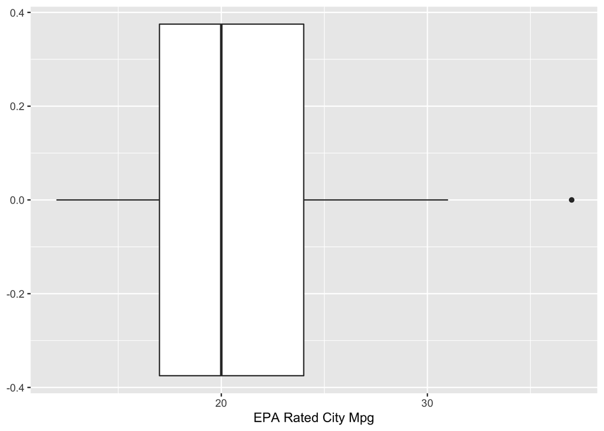

```r
ggplot(data = cars) +
  xlab("EPA Rated City Mpg") +
  geom_boxplot(mapping = aes(x = CityMPG))
```

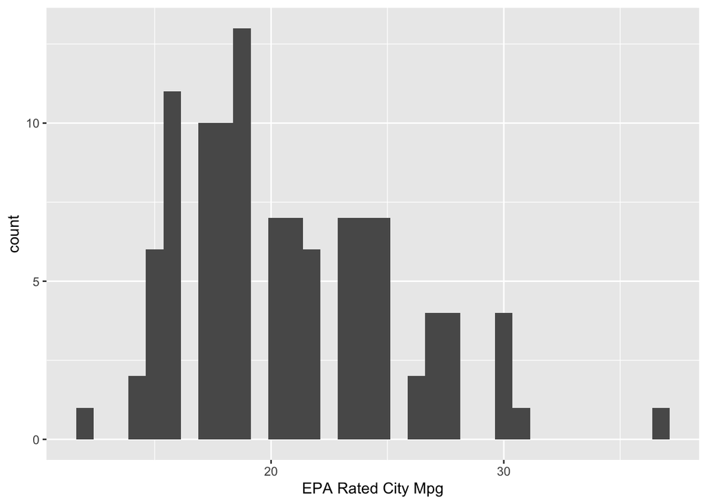

```r
ggplot(data = cars) +
  xlab("EPA Rated City Mpg") +
  geom_histogram(mapping = aes(x = CityMPG), binwidth = 0.75)
```

From both of the above graphics, we can see that a majority of the observations in the dataset revolve around the ~20mpg area. There are a few concerning outliers above 30mpg, so let’s dig deeper into those outliers before continuing.

```r
cars_tibble <- as_tibble(cars[1:8])
cars_tibble %>% filter(CityMPG > 30)
```

| Make | Model | Type | LowPrice | HighPrice | Drive | CityMPG | HwyMPG |
| --- | --- | --- | --- | --- | --- | --- | --- |
| Mitsubishi | Mirage | Hatchback | 12.995 | 15.395 | FWD | 37 | 44 |
| Nissan | Versa Note | Hatchback | 14.180 | 17.960 | FWD | 31 | 40 |

From what we can see above, although these outliers originally appeared to be incorrect data, we can make the assumption that they are in fact correct. Not only can we fact check this ([2015 Mirage MPG](https://www.google.com/search?q=2015+mirage+mpg&oq=2015+mirage+mpg) | [2015 Versa Note MPG](https://www.google.com/search?q=2015+versa+note+mpg)), we can also base our assumption off of the fact that they are both relatively small hatchbacks and compare that to similar vehicles in that category.

##### Explanatory Variable 1

In order to find predictors of our response variable (`CityMPG`), let’s use a correlation matrix. Although this was generalized previously, we need to find the finite list of columns which are numerical in order to predict the response variable. We’re going to approach this model building from the “bottom up”, where we find highly correlated variables and work from there.

```r
# Pull the complete columns from the dataset
numerical_columns <- cars[complete.cases(cars), ]

# Pull the complete numerical columns from the dataset
# Correlation matrix
complete_numerical_columns <- numerical_columns[, sapply(numerical_columns, is.numeric)]
print(round(cor(complete_numerical_columns), 2))
```

```
##           LowPrice HighPrice CityMPG HwyMPG FuelCap Length Width Wheelbase
## LowPrice      1.00      0.91   -0.65  -0.59    0.57   0.47  0.48      0.46
## HighPrice     0.91      1.00   -0.56  -0.49    0.47   0.39  0.37      0.39
## CityMPG      -0.65     -0.56    1.00   0.93   -0.77  -0.72 -0.78     -0.69
## HwyMPG       -0.59     -0.49    0.93   1.00   -0.75  -0.64 -0.75     -0.64
## FuelCap       0.57      0.47   -0.77  -0.75    1.00   0.82  0.85      0.79
## Length        0.47      0.39   -0.72  -0.64    0.82   1.00  0.81      0.92
## Width         0.48      0.37   -0.78  -0.75    0.85   0.81  1.00      0.76
## Wheelbase     0.46      0.39   -0.69  -0.64    0.79   0.92  0.76      1.00
## Height        0.02     -0.10   -0.39  -0.54    0.58   0.46  0.62      0.49
## UTurn         0.40      0.31   -0.73  -0.68    0.76   0.84  0.77      0.81
## Weight        0.55      0.43   -0.83  -0.84    0.91   0.82  0.91      0.81
## Acc030       -0.76     -0.74    0.64   0.51   -0.47  -0.38 -0.41     -0.31
## Acc060       -0.74     -0.72    0.68   0.52   -0.49  -0.47 -0.46     -0.38
## QtrMile      -0.76     -0.76    0.65   0.49   -0.45  -0.42 -0.41     -0.35
## PageNum      -0.23     -0.20    0.28   0.15   -0.15  -0.23 -0.20     -0.24
##           Height UTurn Weight Acc030 Acc060 QtrMile PageNum
## LowPrice    0.02  0.40   0.55  -0.76  -0.74   -0.76   -0.23
## HighPrice  -0.10  0.31   0.43  -0.74  -0.72   -0.76   -0.20
## CityMPG    -0.39 -0.73  -0.83   0.64   0.68    0.65    0.28
## HwyMPG     -0.54 -0.68  -0.84   0.51   0.52    0.49    0.15
## FuelCap     0.58  0.76   0.91  -0.47  -0.49   -0.45   -0.15
## Length      0.46  0.84   0.82  -0.38  -0.47   -0.42   -0.23
## Width       0.62  0.77   0.91  -0.41  -0.46   -0.41   -0.20
## Wheelbase   0.49  0.81   0.81  -0.31  -0.38   -0.35   -0.24
## Height      1.00  0.55   0.71   0.21   0.21    0.25    0.06
## UTurn       0.55  1.00   0.80  -0.36  -0.41   -0.37   -0.22
## Weight      0.71  0.80   1.00  -0.41  -0.43   -0.39   -0.20
## Acc030      0.21 -0.36  -0.41   1.00   0.95    0.95    0.25
## Acc060      0.21 -0.41  -0.43   0.95   1.00    0.99    0.26
## QtrMile     0.25 -0.37  -0.39   0.95   0.99    1.00    0.26
## PageNum     0.06 -0.22  -0.20   0.25   0.26    0.26    1.00
```

```r
# Covariance matrix
print(round(cov(complete_numerical_columns), 2))
```

```
##           LowPrice HighPrice  CityMPG   HwyMPG FuelCap   Length   Width
## LowPrice    253.65    406.94   -46.81   -52.27   39.95   108.19   27.57
## HighPrice   406.94    795.07   -71.27   -75.96   57.62   158.00   38.25
## CityMPG     -46.81    -71.27    20.67    23.51  -15.34   -47.43  -12.94
## HwyMPG      -52.27    -75.96    23.51    30.66  -18.28   -50.99  -15.01
## FuelCap      39.95     57.62   -15.34   -18.28   19.13    51.77   13.54
## Length      108.19    158.00   -47.43   -50.99   51.77   209.32   42.46
## Width        27.57     38.25   -12.94   -15.01   13.54    42.46   13.18
## Wheelbase    56.97     85.70   -24.46   -27.63   26.74   103.49   21.36
## Height        2.53    -17.71   -11.57   -19.79   16.63    44.24   14.77
## UTurn        14.73     20.39    -7.73    -8.78    7.71    28.30    6.51
## Weight     7601.55  10410.32 -3261.20 -4026.01 3453.88 10282.47 2854.44
## Acc030       -6.67    -11.48     1.62     1.57   -1.13    -3.02   -0.83
## Acc060      -19.47    -33.31     5.07     4.71   -3.51   -11.10   -2.77
## QtrMile     -15.95    -27.95     3.85     3.54   -2.55    -7.88   -1.96
## PageNum    -132.93   -209.70    47.57    31.10  -23.98  -121.40  -26.59
##           Wheelbase  Height   UTurn    Weight  Acc030  Acc060 QtrMile  PageNum
## LowPrice      56.97    2.53   14.73   7601.55   -6.67  -19.47  -15.95  -132.93
## HighPrice     85.70  -17.71   20.39  10410.32  -11.48  -33.31  -27.95  -209.70
## CityMPG      -24.46  -11.57   -7.73  -3261.20    1.62    5.07    3.85    47.57
## HwyMPG       -27.63  -19.79   -8.78  -4026.01    1.57    4.71    3.54    31.10
## FuelCap       26.74   16.63    7.71   3453.88   -1.13   -3.51   -2.55   -23.98
## Length       103.49   44.24   28.30  10282.47   -3.02  -11.10   -7.88  -121.40
## Width         21.36   14.77    6.51   2854.44   -0.83   -2.77   -1.96   -26.59
## Wheelbase     60.57   25.36   14.70   5446.45   -1.35   -4.90   -3.53   -69.23
## Height        25.36   43.59    8.46   4056.04    0.77    2.24    2.19    13.55
## UTurn         14.70    8.46    5.45   1613.01   -0.46   -1.59   -1.14   -19.08
## Weight      5446.45 4056.04 1613.01 752549.45 -199.17 -620.70 -439.80 -6512.19
## Acc030        -1.35    0.77   -0.46   -199.17    0.31    0.87    0.69     5.17
## Acc060        -4.90    2.24   -1.59   -620.70    0.87    2.71    2.14    15.64
## QtrMile       -3.53    2.19   -1.14   -439.80    0.69    2.14    1.72    12.34
## PageNum      -69.23   13.55  -19.08  -6512.19    5.17   15.64   12.34  1359.08
```

From the correlation display above, we can see quite a few correlations between `CityMPG` and other numerical variables. Let’s start with the correlation between `CityMPG` and `FuelCap`. This is an interesting combination of variables because they are NEGATIVELY correlated with eachother. To be precise, they are correlated at `-0.77`–Which is logical, as `CityMPG` increases, the need for a higher gasoline capacity decreases (More fuel efficient).

Let’s analyze this relationship with a simple linear model.

```r
model1 <- lm(CityMPG ~ FuelCap, data = complete_numerical_columns)
summary(model1)
```

```
##
## Call:
## lm(formula = CityMPG ~ FuelCap, data = complete_numerical_columns)
##
## Residuals:
##     Min      1Q  Median      3Q     Max
## -5.3846 -1.9837 -0.5216  1.6252  9.1593
##
## Coefficients:
##             Estimate Std. Error t value Pr(>|t|)
## (Intercept) 35.21671    1.17880   29.88   <2e-16 ***
## FuelCap     -0.80174    0.06364  -12.60   <2e-16 ***
## ---
## Signif. codes:  0 '***' 0.001 '**' 0.01 '*' 0.05 '.' 0.1 ' ' 1
##
## Residual standard error: 2.906 on 108 degrees of freedom
## Multiple R-squared:  0.5951, Adjusted R-squared:  0.5913
## F-statistic: 158.7 on 1 and 108 DF,  p-value: < 2.2e-16
```

We can see from the above calculations that both our regular p-value and anova f-statistic P-value is extremely small `2e-16`, which is a good indication of a predictor variable. Additionally the $R^2$ value of `~0.60` (60%) isn’t fantastic, but it isn’t too weak to account for variability in the response variable.

Let’s visualize the above correlations .

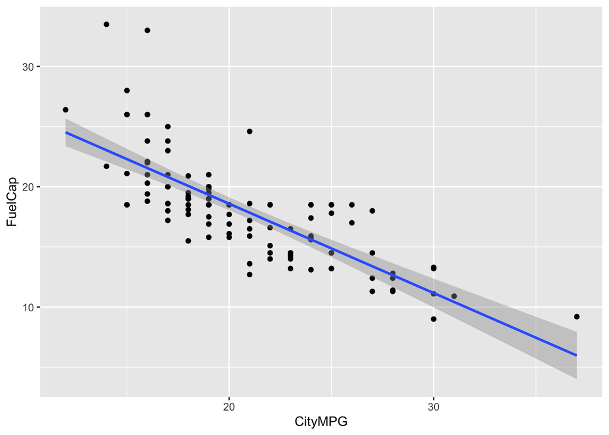

```r
ggplot(data = complete_numerical_columns, aes(x = CityMPG, y = FuelCap), na.rm = TRUE) +
  geom_point() +
  geom_smooth(method = 'lm')
```

Next let’s run the standard residuals diagnostics on our first predictor variable.

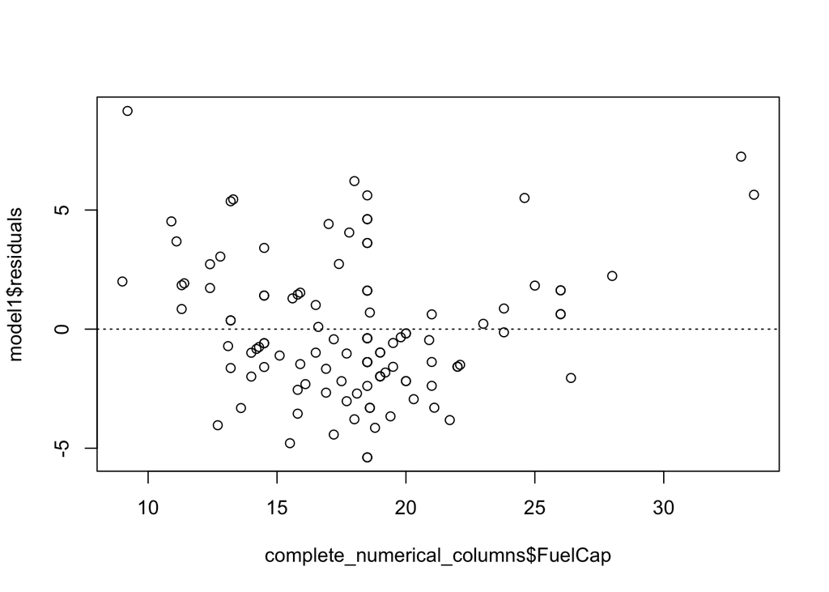

```r
# Check for linearity
plot(model1$residuals ~ complete_numerical_columns$FuelCap)
abline(h = 0, lty = 3)
```

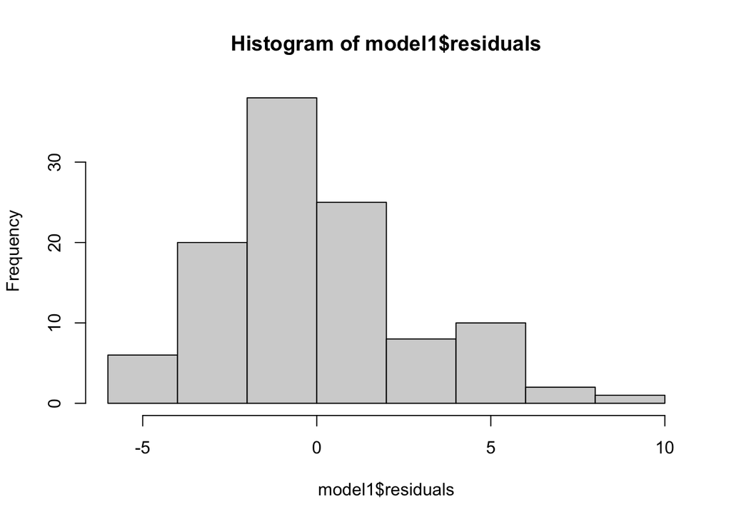

```r
# Check for normality (1/2)
hist(model1$residuals)
```

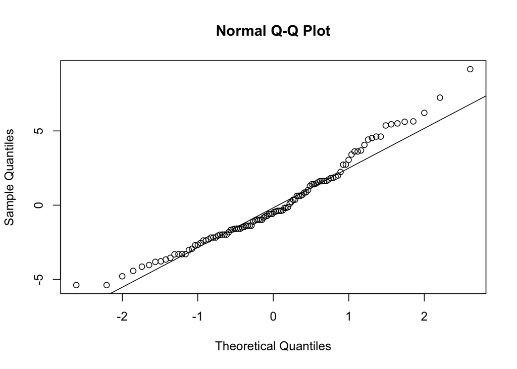

```r
# Check for normality (2/2)
qqnorm(model1$residuals)
qqline(model1$residuals)
```

From the above three diagrams, we can conclude:

1. The variable likely does not meet the linearity requirements; The response variable is not evenly scattered, and heavily condensed around the 15-20gal range (Linearity)
2. Based off of the histogram, we can see the distribution is relatively normal (Normality)
3. Similar to our linearity requirement, we don’t neccesarily have equal variance as required. (Equal variance)

##### Explanatory Variable 2

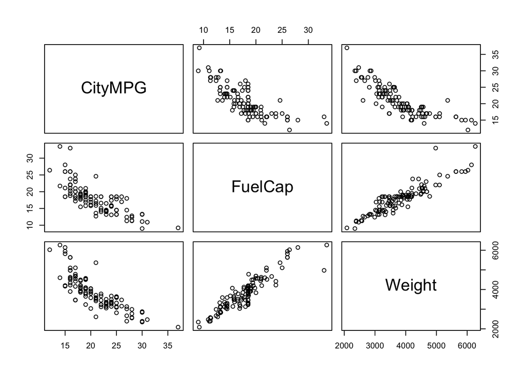

```r
plot(cars[c(7, 9, 15)])
```

```r
model2 <- lm(CityMPG ~ Weight, data = complete_numerical_columns)
summary(model2)
```

```
##
## Call:
## lm(formula = CityMPG ~ Weight, data = complete_numerical_columns)
##
## Residuals:
##    Min     1Q Median     3Q    Max
## -5.455 -1.548 -0.166  1.540  8.587
##
## Coefficients:
##               Estimate Std. Error t value Pr(>|t|)
## (Intercept) 37.4486063  1.1177208   33.50   <2e-16 ***
## Weight      -0.0043335  0.0002836  -15.28   <2e-16 ***
## ---
## Signif. codes:  0 '***' 0.001 '**' 0.01 '*' 0.05 '.' 0.1 ' ' 1
##
## Residual standard error: 2.568 on 108 degrees of freedom
## Multiple R-squared:  0.6838, Adjusted R-squared:  0.6809
## F-statistic: 233.6 on 1 and 108 DF,  p-value: < 2.2e-16
```

As with the first explanatory variable, the p-value is extremely small (`2e-16`), which is a great sign that it’s statistically significant. Our $R^2$ value is also decently high at `~0.68`, which equates to a reasonably strong correlation between the two variables `CityMPG` and `Weight`.

Let’s visualize the calculations above.

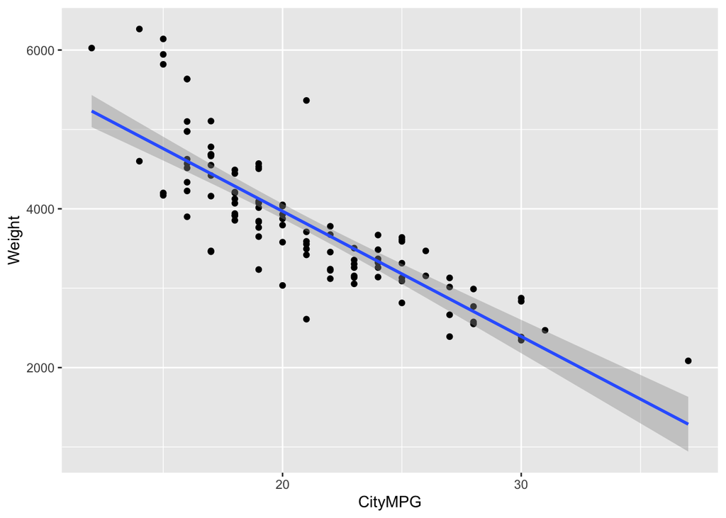

```r
ggplot(data = complete_numerical_columns, aes(x = CityMPG, y = Weight), na.rm = TRUE) +
  geom_point() +
  geom_smooth(method = 'lm')
```

We can see almost the same data trend as with `FuelCap` in this graph. Following suite to the standard diagnostic procedures we performed for the first model, let’s run through a few diagnostics to ensure our predicted explanatory variable works well.

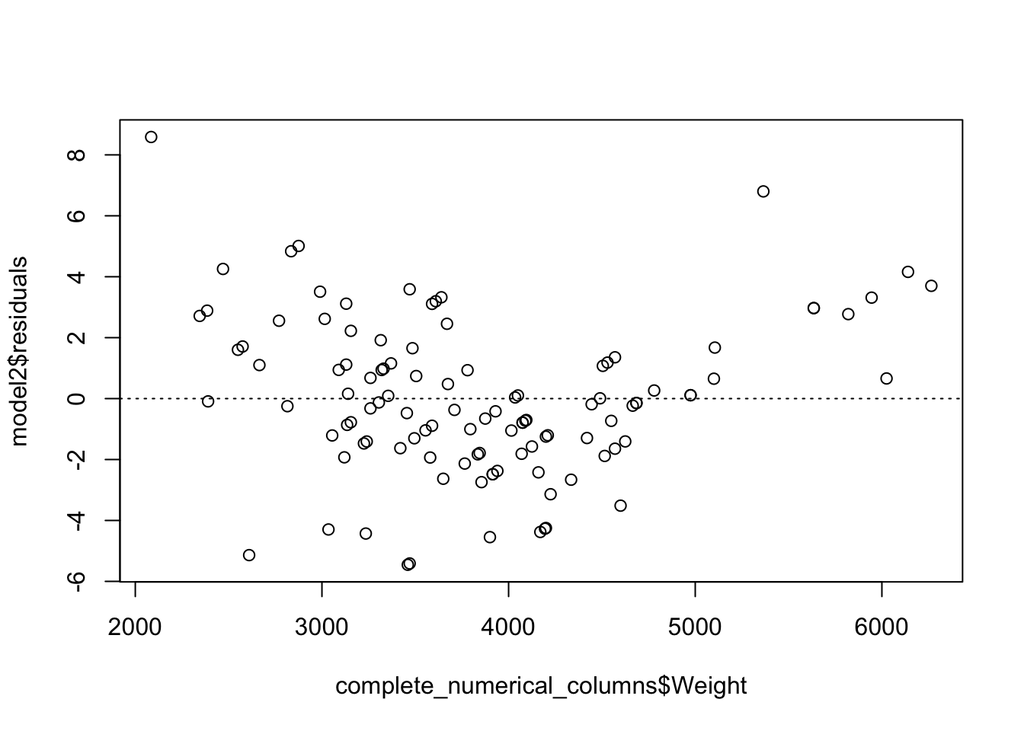

```r
# Check for linearity
plot(model2$residuals ~ complete_numerical_columns$Weight)
abline(h = 0, lty = 3)
```

The data does display some trending, but it’s spread considerably better than model1. Let’s check for normality among distribution.

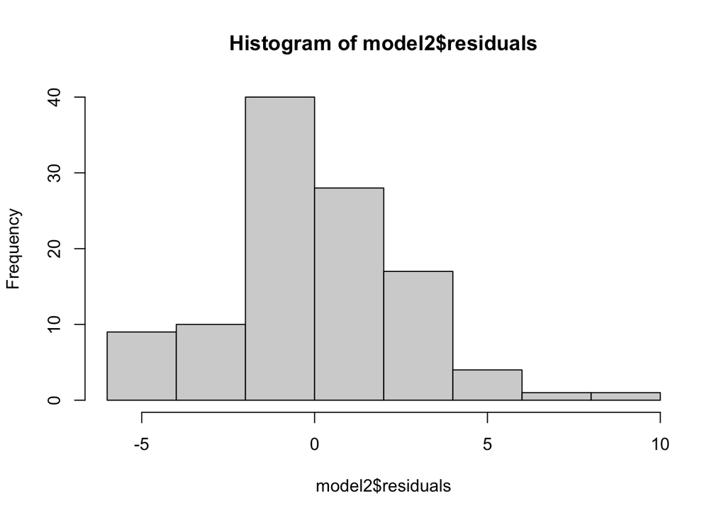

```r
# Check for normality (1/2)
hist(model2$residuals)
```

The data does appear to be somewhat centered around zero, with a slight right-tail. Using `qqnorm` we can check for normality in a different way.

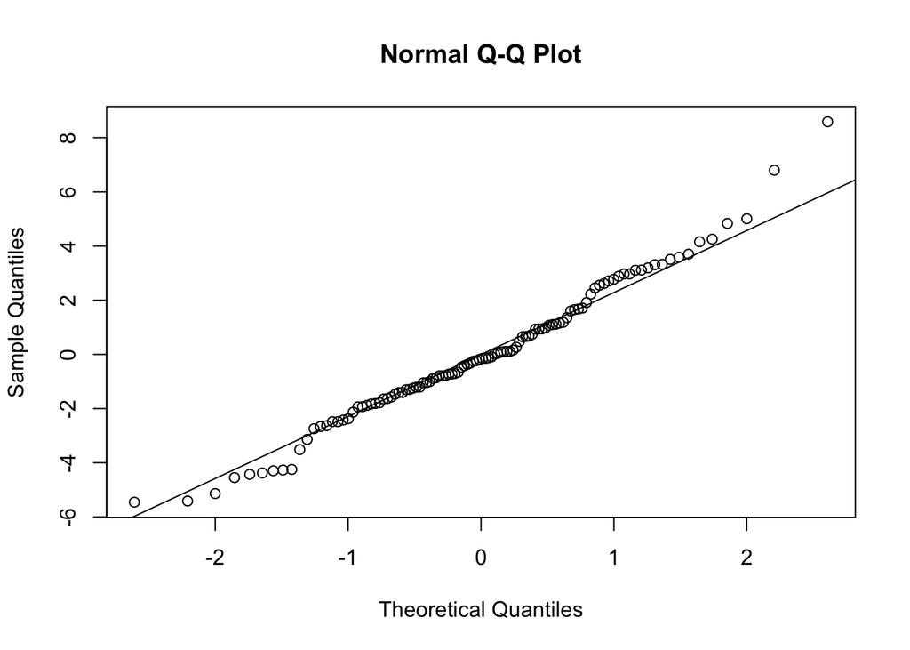

```r
# Check for normality (2/2)
qqnorm(model2$residuals)
qqline(model2$residuals)
```

##### Final Regression Model

Pulling all of this data together, let’s build the final model with `FuelCap` and `Weight` as the explanatory variables and `CityMPG` as the response variable.

```r
model3 <- lm(CityMPG ~ FuelCap + Weight, data = complete_numerical_columns)
summary(model3)
```

```
##
## Call:
## lm(formula = CityMPG ~ FuelCap + Weight, data = complete_numerical_columns)
##
## Residuals:
##     Min      1Q  Median      3Q     Max
## -5.3447 -1.5551 -0.2244  1.4628  8.5048
##
## Coefficients:
##               Estimate Std. Error t value Pr(>|t|)
## (Intercept) 37.4887087  1.1203171  33.463   <2e-16 ***
## FuelCap     -0.1135817  0.1359716  -0.835    0.405
## Weight      -0.0038122  0.0006856  -5.560    2e-07 ***
## ---
## Signif. codes:  0 '***' 0.001 '**' 0.01 '*' 0.05 '.' 0.1 ' ' 1
##
## Residual standard error: 2.572 on 107 degrees of freedom
## Multiple R-squared:  0.6859, Adjusted R-squared:   0.68
## F-statistic: 116.8 on 2 and 107 DF,  p-value: < 2.2e-16
```

As a quick recap of the model diagnostics, we can run a residual error calculation to see the percentage of error in our model’s calculations.

```r
print(sigma(model3) / mean(complete_numerical_columns$CityMPG))
```

```
## [1] 0.1237512
```

```r
# Analysis of Variance
anova(model3)
```

|  | Df | Sum Sq | Mean Sq | F value | Pr(>F) |
| --- | --- | --- | --- | --- | --- |
| FuelCap | 1 | 1340.5756 | 1340.575595 | 202.68663 | 1.922579e-26 |
| Weight | 1 | 204.4867 | 204.486740 | 30.91711 | 1.997798e-07 |
| Residuals | 107 | 707.7013 | 6.614031 | NA | NA |

```r
# Outliers (Bonferonni)
outlierTest(model3)
```

```
## No Studentized residuals with Bonferroni p < 0.05
## Largest |rstudent|:
##   rstudent unadjusted p-value Bonferroni p
## 4 3.571288         0.00053569     0.058926
```

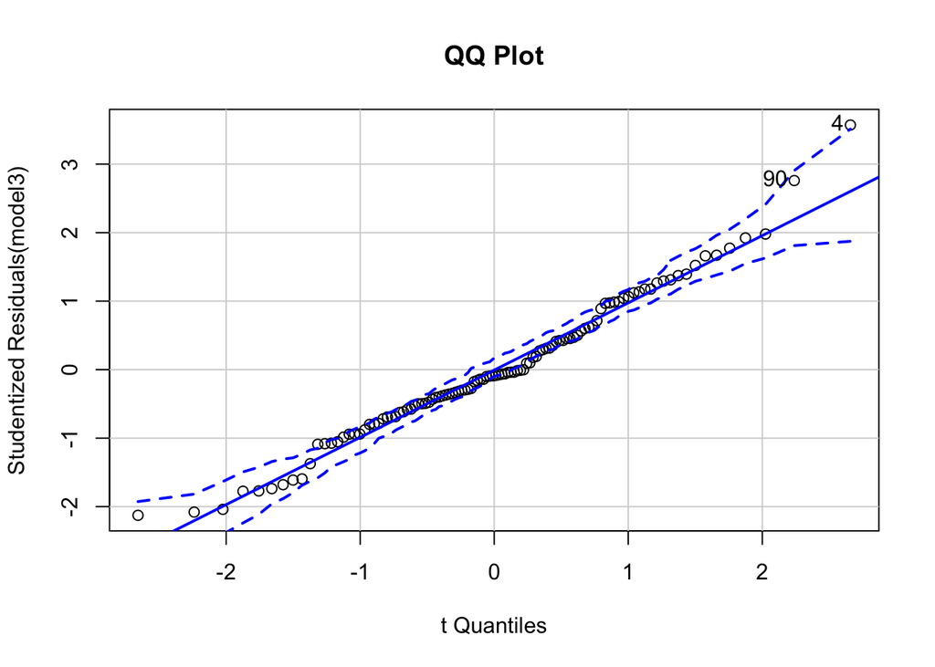

```
## [1]  4 90
```

```r
# QQ Plot
qqPlot(model3, main = "QQ Plot")
```

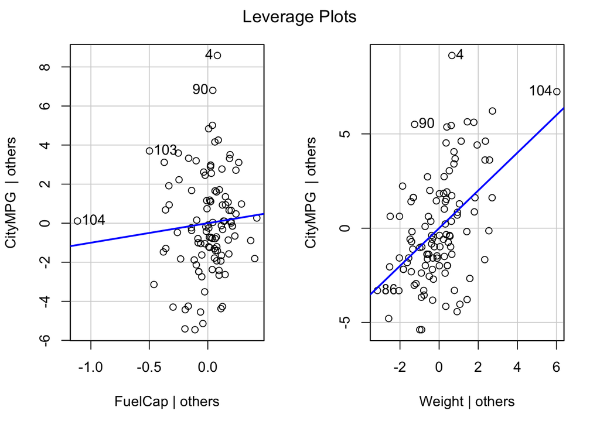

```r
# Leverage Points in data
leveragePlots(model3)
```

Both the anova and bonferonni tests come up indicating that we have no significant issues with outliers in our dataset or analysis. Additionally, if we wanted to test the variance across multiple different models, we could run the anova test with each different model (I.E. `anova(model1, model2)`). However, because I built the model from the ground up, I don’t need to throw in guesswork as to which model would be most appropriate for this task.

##### Summary

We do see a strong correlation between the `CityMPG`, `Weight`, and `FuelCap` variables. I am failing to reject the null hypothesis ($H_0$) due to this fact. See Recommendations below for a more in-depth summary.

## Recommendations

##### Analysis 1:

my estimate is the type of drive and the size of a car are dependent, I thought AWD cars’ size will larger than FWD cars and RWD cars. However, analysis#1 proves my guess is wrong. Based on the sample data, we get there is no significant evidence to conclude that there is an association between the type of drive and the size of the car at the 95% confidence level. One limitation in my finding is the sample size is not representative enough for all cars in 2015.

##### Analysis 4:

My goal in the analysis was to prove a relationship between the response variable City MPG and explanatory variables Dry Weight and Fuel Tank Capacity. The efforts to do so were successful, and there was found to be a negative correlation between the `CityMPG`:`FuelCap`. This relationship is nothing short of expected, as the fuel efficiency of a engine increases, one would expect that the need for a larger fuel tank decreases. Beyond fuel tank capacity, I also found that there was once again a negative linear correlation between `CityMPG`:`Weight`; As the `CityMPG` went up, the vehicle’s weight went down. Need I repeat, this was not unexpected, heavy vehicles need larger engines, and larger engines mean more fuel consumption (Lower MPGs). I don’t believe there are any limitations to the findings in this dataset, the only future limitation would be if eMPG (Electric simulated MPG) were included (I.E. Telas/Chevy Volt). This addition would skew the data in many unfavorable ways. I would suspect that this analysis did not present any new findings to the reader, as it’s all basic logic.

## Reflections

##### Alec Mattu:

I would say that the three unit projects significantly expanded my understanding of performing statistical analyses. Not only did it provide and opportunity to perform three independent analyses on the same dataset from different perspectives, it also provided the chance to view fellow student’s ways of performing statistical functions and tasks. In summary, these past three projects allowed me to personally explore: Analysis on a single categorical variable, draw inferences on a single categorical proportion, and finally, multiple linear regression on two quantitative variables and one response variable. While I learned a plethora of things from unit projects, I would say that the most important is how to implement linear regression on multiple variables (categorical and numerical). Thankfully, I personally faced very few challenges when completing these unit projects–The only initial hiccup was setting up proper `.Rmd` file exporting to HTML/PDFs.

##### Yiling Du:

Three Unit Projects help me to use the statistics knowledge I learned in class in a real data file. I learned how to use R language to analyze big data. Because of the Unit projects, I got more familiar to write R code. In addition, I learned we can get a lot of information through analyzing a data file, such as we made five different analyses for each unit project and we have different interesting findings for each analysis. I have not faced many challenges in completing the unit projects because the R demo videos cover most of the skills to use R.